# Analysis of data

Miguel Quero Carboneras

2022-10-27

## Precedente y objetivos

Partimos de los datos limpios y ordenados (vease **processing_of_data.Rmd**). En esta limpieza se han eliminado columnas que no eran útiles y se ha disgregado la información de algunas columnas en otras más específicas. Además se ha sintetizado la duración de los viajes en segundos.

El objetivo principal del analisis es comparar el uso que hacen los miembros y los usuarios anuales de las bicicletas, en cuestion de tiempo usando la bicicleta y los días de la semana en los que se hace el uso.

## Cargar los datos y revisión previa

Lo primero es cargar las librerias:

```r
library(tidyverse)
library(lubridate)
```

Lo segundo es importar el archivo *.csv* con los datos:

```r
setwd("C:/Users/migue/OneDrive/Escritorio/GitHub/Data_analysis_bicycles/Data/1_prepared_&_processed_data")
trips_202110_202209_clean <- read_csv("trips_202110_202209_processed.csv")
```

```
## * `` -> ...1
```

Al revisar el documento me he dado cuenta de que los días de la semana están en castellano y no se reconocen los acentos por lo que voy a ponerlos en inglés:

```r
trips_202110_202209_clean %>%
  mutate(day_of_week = recode(day_of_week,
                                "lunes" = "monday",
                                "martes" = "tuesday",
                              "jueves" = "thursday",
                              "viernes" = "friday",
                              "domingo" = "sunday")) -> trips_202110_202209_clean

trips_202110_202209_clean[grepl("rcoles",
                                trips_202110_202209_clean$day_of_week),
                          "day_of_week"] <- "wednesday"

trips_202110_202209_clean[grepl("bado",
                                trips_202110_202209_clean$day_of_week),
                          "day_of_week"] <- "saturday"
```

## Análisis de *ride_length* de cada tipo de usuario

```r
summary(trips_202110_202209_clean$ride_length)
```

```
##    Min. 1st Qu.  Median    Mean 3rd Qu.    Max.
##       1     367     644    1244    1157 2442301
```

Los datos de mediana, mínimo y maximo no son de especial relevancia para el analisis; en especial el maximo y el mínimo que parecen representar casos erroneos. Sería más relevante para un análisis más en profundidad los cuartiles o deciles. Por el momento me voy a analizar los datos a nivel de media.

Una vez conocida la media general de los viajes (1244 segundos o unos 20 minutos), voy a compararlo con la media para cada tipo de usuario.

```r
aggregate(trips_202110_202209_clean$ride_length ~
            trips_202110_202209_clean$member_casual,
          FUN = mean)
```

```
##   trips_202110_202209_clean$member_casual trips_202110_202209_clean$ride_length
## 1                                  casual                             1915.5864
## 2                                  member                              775.1481
```

```r
sum(trips_202110_202209_clean$member_casual == "member") * 100 / nrow(trips_202110_202209_clean)
```

```
## [1] 58.9083
```

```r
sum(trips_202110_202209_clean$member_casual == "casual") * 100 / nrow(trips_202110_202209_clean)
```

```
## [1] 41.0917
```

Los usuarios casuales son el 41.1% del total, lo cual confirma la importancia de este análisis para conseguir que estas personas adquieran la membresia anual.

## Análisis del *ride_length* en cada día de la semana

Voy a ver en que día de la semana se hace un mayor uso de las bicicletas por parte de cada tipo de usuario.

```r
aggregate(trips_202110_202209_clean$ride_length ~ trips_202110_202209_clean$member_casual +
            trips_202110_202209_clean$day_of_week, FUN = mean)
```

```
##    trips_202110_202209_clean$member_casual
## 1                                   casual
## 2                                   member
## 3                                   casual
## 4                                   member
## 5                                   casual
## 6                                   member
## 7                                   casual
## 8                                   member
## 9                                   casual
## 10                                  member
## 11                                  casual
## 12                                  member
## 13                                  casual
## 14                                  member
##    trips_202110_202209_clean$day_of_week trips_202110_202209_clean$ride_length
## 1                                 friday                             1836.3735
## 2                                 friday                              759.5531
## 3                                 monday                             1943.2056
## 4                                 monday                              748.8022
## 5                               saturday                             2119.0864
## 6                               saturday                              869.5427
## 7                                 sunday                             2230.5024
## 8                                 sunday                              866.1011
## 9                               thursday                             1677.1346
## 10                              thursday                              746.5639
## 11                               tuesday                             1686.2881
## 12                               tuesday                              737.1415
## 13                             wednesday                             1632.8772
## 14                             wednesday                              734.3138
```

## Análisis del número de viajes de cada usuario por semana

Ahora voy a sacar que días de la semana hay mayor número de viajes por tipo de usuario.

```r
trips_202110_202209_clean %>%
  mutate(day_week = wday(started_at, label = TRUE)) %>%
  group_by(member_casual, day_week) %>%
  summarise(number_of_rides = n()) %>%
  arrange(member_casual, day_week) %>%
  mutate(day_week = recode(day_week,
                           "do\\." = "Sunday",
                           "lu\\." = "Monday",
                           "ma\\." = "Tuesday",
                           "mi\\." = "Wednesday",
                           "ju\\." = "Thursday",
                           "vi\\." = "Friday",
                           "sá\\." = "Saturday"))
```

```
## # A tibble: 14 x 3
## # Groups:   member_casual [2]
##    member_casual day_week  number_of_rides
##    <chr>         <ord>               <int>
##  1 casual        Sunday             347461
##  2 casual        Monday             235852
##  3 casual        Tuesday            230088
##  4 casual        Wednesday          234608
##  5 casual        Thursday           255459
##  6 casual        Friday             294140
##  7 casual        Saturday           429307
##  8 member        Sunday             330366
##  9 member        Monday             403729
## 10 member        Tuesday            464144
## 11 member        Wednesday          459946
## 12 member        Thursday           449671
## 13 member        Friday             413241
## 14 member        Saturday           384651
```

## Resultado conjunto

Por último, voy a generar una tabla con los dos últimos resultados combinados.

```r
trips_202110_202209_clean %>%
  mutate(day_week = wday(started_at, label = TRUE)) %>%
  group_by(member_casual, day_week) %>%
  summarise(number_of_rides = n(),
            average_duration = (mean(ride_length))/60,
             se_duration = sd(ride_length/60)/sqrt(n())) %>%
  arrange(member_casual, day_week)  %>%
  mutate(day_week = recode(day_week,
                           "do\\." = "Sunday",
                           "lu\\." = "Monday",
                           "ma\\." = "Tuesday",
                           "mi\\." = "Wednesday",
                           "ju\\." = "Thursday",
                           "vi\\." = "Friday",
                           "sá\\." = "Saturday")) -> summary
```

## Visualizaciones

Este primer análisis me ha servido para hacerme una idea del panorama general. Para que sea más claro el resultado voy a mostrarlo con visualizaciones de lo más genérico hasta lo más específico.

### Proporción de cada tipo de usuarios

En el siguiente pie chard se observa que proporción de los usurios totales de este año son casuales y cuales miembros.

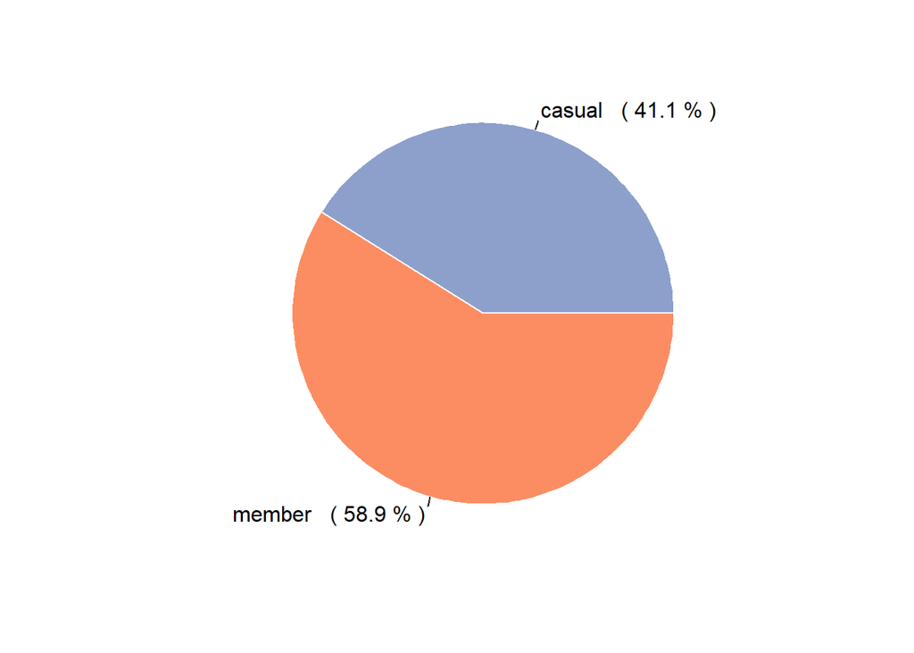

### Número de viajes por mes y tipo de usuario

Con el siguiente gráfico nos podemos hacer una idea de la existencia o no de estacionalidad a lo largo del año entre cada tipo de usuario.

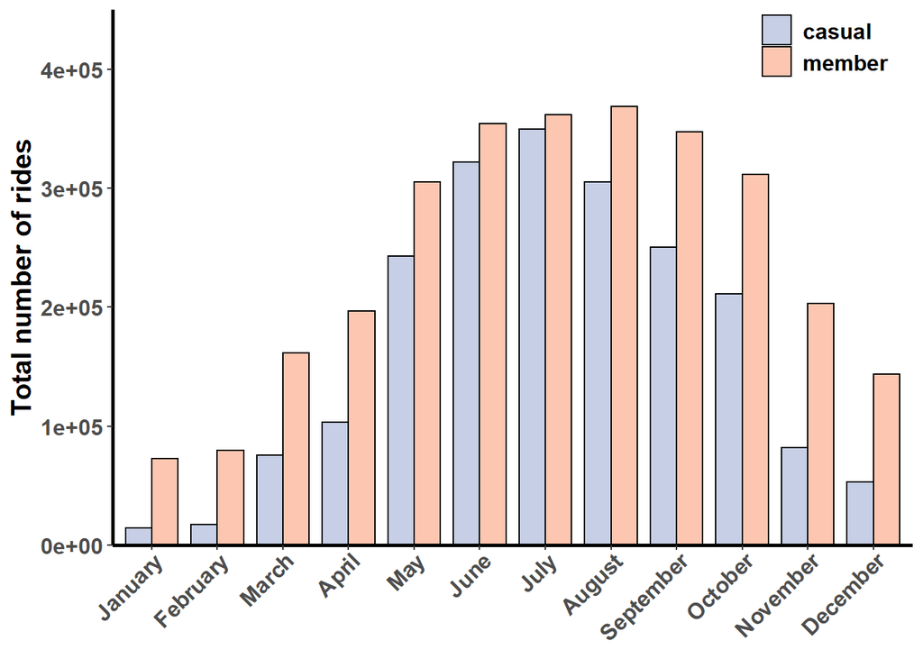

### Número de viajes por día de la semana de cada tipo de usurio

Este es el primero de los resultados más específicos a nivel de día de la semana.

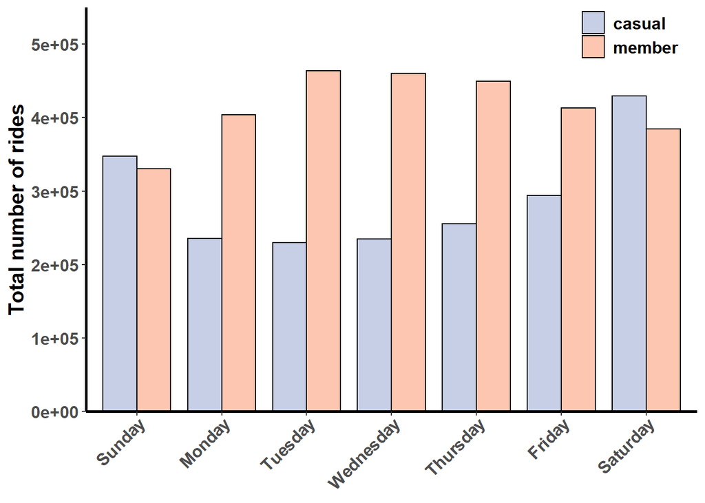

### Longitud de los viajes por día de la semana y tipo de usurio

Este último gráfico nos ayuda a comparar la duración de los viajes de forma más espcífica.

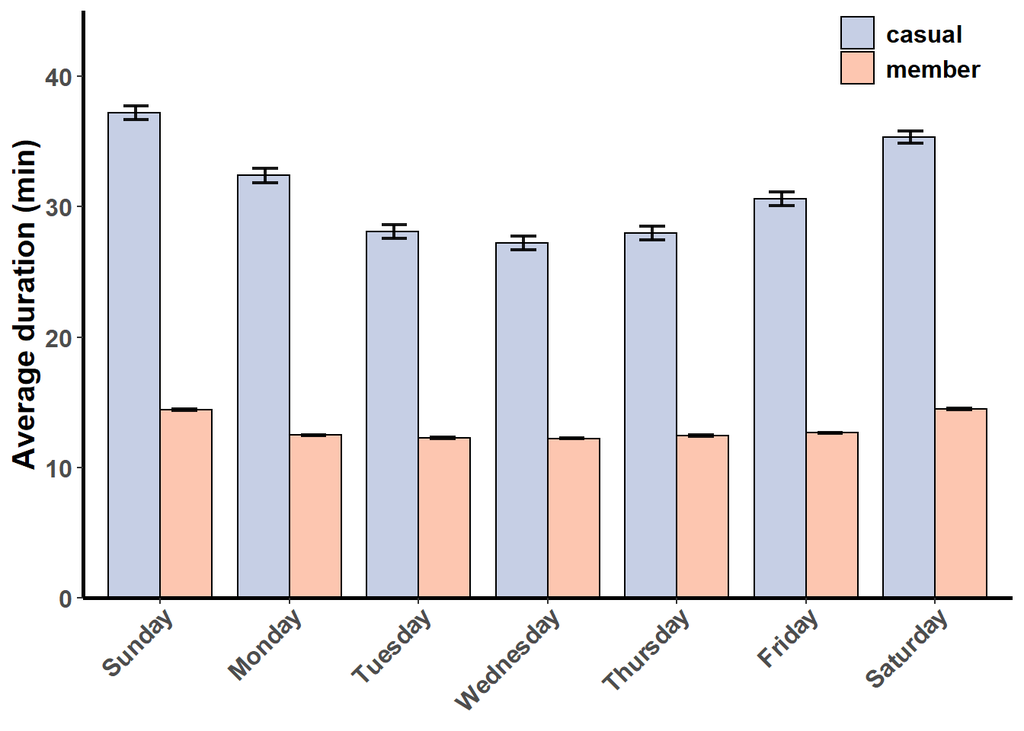